# Description

#### Observation:

- Number of children accompanied duuring travel has no impact on the package purchse.

```
ProdTaken          0    1   All
Designation
AVP              322   20   342
Executive       1290  552  1842
Manager         1528  204  1732
Senior Manager   618  124   742
VP               210   20   230
All             3968  920  4888
------------------------------------------------------------------------------------------------------------------------
```

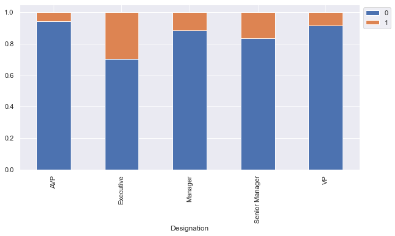

```python
### ProdTaken vs Designation
stacked_plot(data["Designation"])
```

#### Observation:

- Executives, Managers and SM purchase more package.

```
ProdTaken                  0    1   All
PitchSatisfactionScore
1                        798  144   942
2                        498   88   586
3                       1162  316  1478
4                        750  162   912
5                        760  210   970
All                     3968  920  4888
------------------------------------------------------------------------------------------------------------------------
```

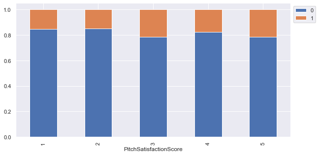

```python
### ProdTaken vs PitchSatisfactionScore
stacked_plot(data["PitchSatisfactionScore"])
```

#### Observation:

```
ProdTaken          0    1   All
ProductPitched
Basic           1290  552  1842
Deluxe          1528  204  1732
King             210   20   230
Standard         618  124   742
Super Deluxe     322   20   342
All             3968  920  4888
------------------------------------------------------------------------------------------------------------------------
```

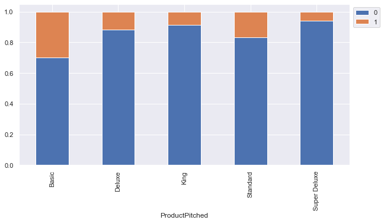

```python
### ProdTaken vs ProductPitched
stacked_plot(data["ProductPitched"])
```

#### Observation:

- Basic and standard as popular packages among other pitched package.

```
ProdTaken             0    1   All
NumberOfFollowups
1.0                 156   20   176
2.0                 205   24   229
3.0                1222  244  1466
4.0                1689  379  2068
5.0                 577  191   768
6.0                  82   54   136
All                3931  912  4843
------------------------------------------------------------------------------------------------------------------------
```

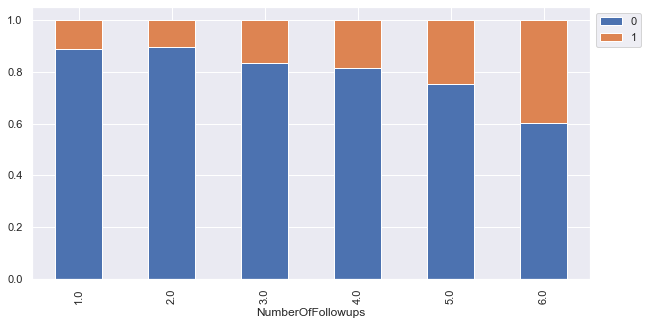

```python
### ProdTaken vs NumberOfFollowups
stacked_plot(data["NumberOfFollowups"])
```

#### Observation:

- More followups leads to more package success rate.

### Function to plot distributions and Boxplots of customers

```python
def customer_plot(x, target="ProdTaken"):
    fig, axs = plt.subplots(2, 2, figsize=(12, 10))
    axs[0, 0].set_title(
        f"Distribution of {x} of people with ProdTaken",
        fontsize=12,
        fontweight="bold",
    )
    sns.distplot(data[(data[target] == 1)][x], ax=axs[0, 0], color="teal")
    axs[0, 1].set_title(
        f"Distribution of {x} of people with out ProdTaken",
        fontsize=12,
        fontweight="bold",
    )
    sns.distplot(data[(data[target] == 0)][x], ax=axs[0, 1], color="orange")
    axs[1, 0].set_title(
        f"Boxplot of {x} w.r.t ProdTaken", fontsize=12, fontweight="bold"
    )

    line = plt.Line2D(
        (0.1, 0.9), (0.5, 0.5), color="grey", linewidth=1.5, linestyle="--"
    )
    fig.add_artist(line)

    sns.boxplot(
        data[target], data[x], ax=axs[1, 0], palette="gist_rainbow", showmeans=True
    )
    axs[1, 1].set_title(
        f"Boxplot of {x} w.r.t ProdTaken - Without outliers",
        fontsize=12,
        fontweight="bold",
    )
    sns.boxplot(
        data[target],
        data[x],
        ax=axs[1, 1],
        showfliers=False,
        palette="gist_rainbow",
        showmeans=True,
    )  # turning off outliers from boxplot
    plt.tight_layout(pad=4)
    plt.show()
```

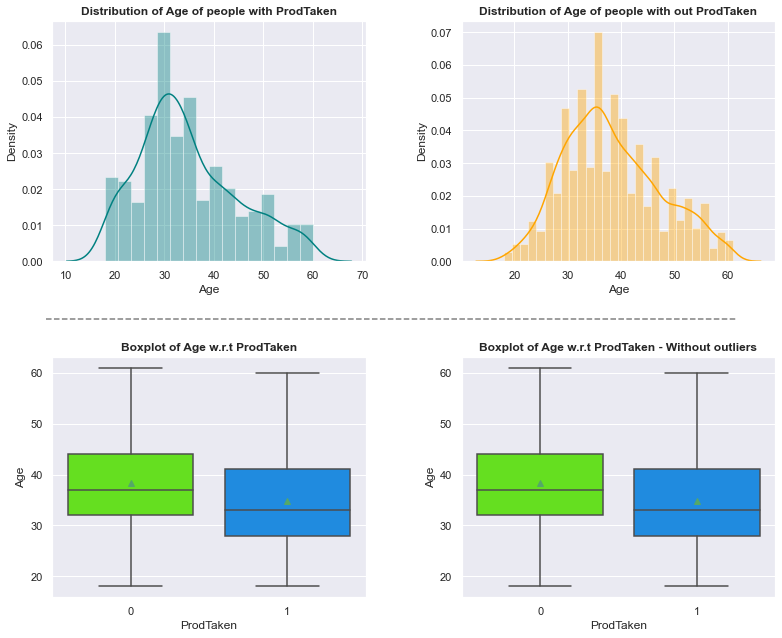

```python
customer_plot("Age")
```

#### Observation:

- Customers with age between 25 and 35 purchase most of the packages

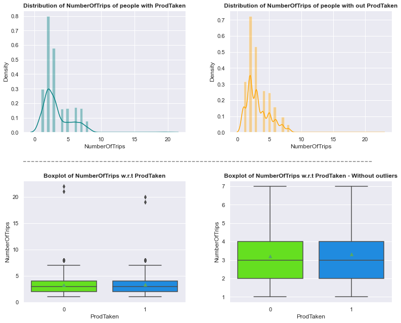

```python
customer_plot("NumberOfTrips")
```

#### Observation:

- There is no discernible co-relation between number of trips and product purchased.
- Both categories has similar relationship with customer number of trips taken.

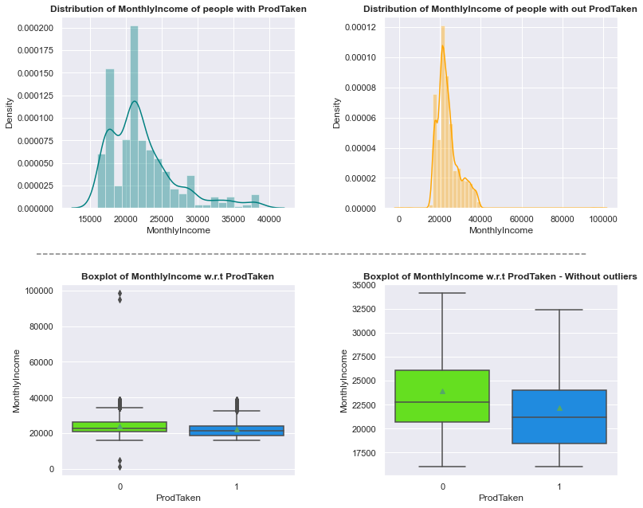

```python
customer_plot("MonthlyIncome")
```

#### Observation:

- Higher monthly income customer do not purchase travel package.

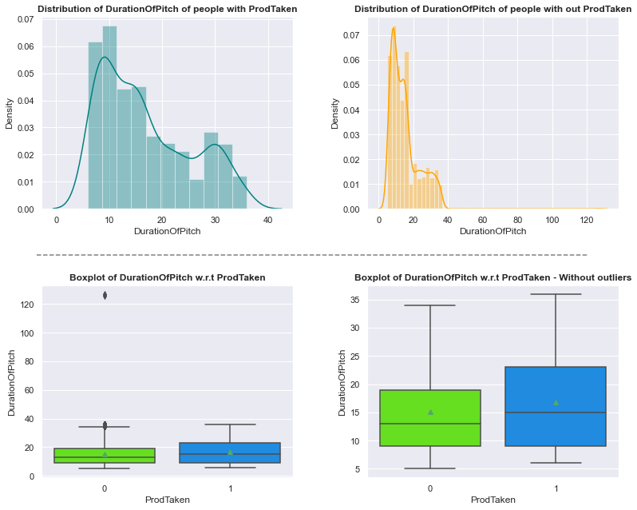

```python
customer_plot("DurationOfPitch")
```

### Data Pre-processing - Prepare the data for analysis.

- Missing value Treatment,
- Outlier Detection and treatment,
- Feature Engineering,
- Prepare data for modeling

```python
missing_check(df)
```

|  | Total | Percent |
| --- | --- | --- |
| DurationOfPitch | 251 | 0.051350 |
| MonthlyIncome | 233 | 0.047668 |
| Age | 226 | 0.046236 |
| NumberOfTrips | 140 | 0.028642 |
| NumberOfChildrenVisiting | 66 | 0.013502 |
| NumberOfFollowups | 45 | 0.009206 |
| PreferredPropertyStar | 26 | 0.005319 |
| TypeofContact | 25 | 0.005115 |
| Designation | 0 | 0.000000 |
| OwnCar | 0 | 0.000000 |
| PitchSatisfactionScore | 0 | 0.000000 |
| Passport | 0 | 0.000000 |
| CustomerID | 0 | 0.000000 |
| MaritalStatus | 0 | 0.000000 |
| ProdTaken | 0 | 0.000000 |
| NumberOfPersonVisiting | 0 | 0.000000 |
| Gender | 0 | 0.000000 |
| Occupation | 0 | 0.000000 |
| CityTier | 0 | 0.000000 |
| ProductPitched | 0 | 0.000000 |

```python
# Checking rows with missing values.
num_missing = df.isnull().sum(axis=1)
num_missing.value_counts()
```

```
0    4128
1     533
2     202
3      25
dtype: int64
```

```python
df[num_missing == 1].sample(n=20)
```

|  | CustomerID | ProdTaken | Age | TypeofContact | CityTier | DurationOfPitch | Occupation | Gender | NumberOfPersonVisiting | NumberOfFollowups | ProductPitched | PreferredPropertyStar | MaritalStatus | NumberOfTrips | Passport | PitchSatisfactionScore | OwnCar | NumberOfChildrenVisiting | Designation | MonthlyIncome |
| --- | --- | --- | --- | --- | --- | --- | --- | --- | --- | --- | --- | --- | --- | --- | --- | --- | --- | --- | --- | --- |
| 1022 | 201022 | 0 | NaN | Company Invited | 1 | 11.0 | Large Business | Male | 2 | 1.0 | Basic | 3.0 | Single | 1.0 | 0 | 5 | 1 | 0.0 | Executive | 18500.0 |
| 2591 | 202591 | 0 | 42.0 | Company Invited | 1 | 17.0 | Salaried | Male | 4 | 5.0 | Super Deluxe | 5.0 | Married | NaN | 0 | 2 | 1 | 1.0 | AVP | 35859.0 |
| 4821 | 204821 | 1 | 45.0 | Self Enquiry | 1 | 30.0 | Small Business | Male | 4 | 4.0 | Basic | 5.0 | Single | NaN | 0 | 3 | 0 | 3.0 | Executive | 36891.0 |
| 3620 | 203620 | 0 | 50.0 | Self Enquiry | 1 | 29.0 | Salaried | Female | 4 | 4.0 | Super Deluxe | 4.0 | Married | 5.0 | 0 | 4 | 0 | NaN | AVP | 35091.0 |
| 2681 | 202681 | 0 | 53.0 | Company Invited | 3 | 9.0 | Salaried | Male | 4 | 5.0 | King | 3.0 | Single | NaN | 1 | 2 | 1 | 3.0 | VP | 37746.0 |
| 1242 | 201242 | 0 | 40.0 | Self Enquiry | 3 | 13.0 | Small Business | Male | 2 | 3.0 | King | 4.0 | Single | 2.0 | 0 | 4 | 1 | NaN | VP | 34833.0 |
| 3143 | 203143 | 0 | 53.0 | Self Enquiry | 1 | 7.0 | Salaried | Male | 4 | 4.0 | Super Deluxe | 3.0 | Divorced | NaN | 0 | 2 | 1 | 2.0 | AVP | 35777.0 |
| 4669 | 204669 | 0 | 46.0 | Self Enquiry | 3 | 18.0 | Salaried | Female | 3 | 4.0 | Super Deluxe | 3.0 | Married | NaN | 0 | 4 | 0 | 2.0 | AVP | 36328.0 |
| 114 | 200114 | 0 | 34.0 | Self Enquiry | 1 | NaN | Salaried | Female | 2 | 4.0 | Deluxe | 4.0 | Married | 7.0 | 0 | 3 | 0 | 1.0 | Manager | 19505.0 |
| 981 | 200981 | 1 | 35.0 | Company Invited | 3 | NaN | Small Business | Female | 3 | 3.0 | Deluxe | 3.0 | Divorced | 1.0 | 1 | 5 | 1 | 2.0 | Manager | 19614.0 |
| 2231 | 202231 | 1 | 36.0 | Self Enquiry | 1 | NaN | Salaried | Male | 2 | 3.0 | Deluxe | 3.0 | Married | 1.0 | 0 | 4 | 0 | 1.0 | Manager | 19834.0 |
| 2109 | 202109 | 0 | NaN | Self Enquiry | 1 | 6.0 | Large Business | Female | 2 | 3.0 | Basic | 5.0 | Married | 3.0 | 0 | 4 | 0 | 0.0 | Executive | 18580.0 |
| 1425 | 201425 | 0 | 33.0 | Self Enquiry | 1 | NaN | Small Business | Female | 3 | 3.0 | Deluxe | 3.0 | Married | 1.0 | 1 | 1 | 1 | 1.0 | Manager | 19878.0 |
| 4641 | 204641 | 0 | 19.0 | Company Invited | 1 | NaN | Salaried | Male | 4 | 4.0 | Basic | 3.0 | Single | 3.0 | 0 | 1 | 0 | 2.0 | Executive | 19729.0 |
| 2852 | 202852 | 0 | 53.0 | Self Enquiry | 1 | 11.0 | Salaried | Female | 2 | 4.0 | Super Deluxe | 3.0 | Divorced | 4.0 | 0 | 5 | 1 | NaN | AVP | 35233.0 |
| 3005 | 203005 | 0 | 53.0 | Self Enquiry | 3 | 10.0 | Small Business | Male | 3 | 5.0 | Super Deluxe | 5.0 | Divorced | 3.0 | 0 | 5 | 1 | NaN | AVP | 35534.0 |
| 4523 | 204523 | 0 | 44.0 | Self Enquiry | 1 | 21.0 | Salaried | Male | 4 | 4.0 | Super Deluxe | 5.0 | Married | NaN | 0 | 5 | 1 | 2.0 | AVP | 35837.0 |
| 2921 | 202921 | 0 | 51.0 | Company Invited | 2 | 10.0 | Small Business | Male | 3 | 4.0 | King | 4.0 | Divorced | NaN | 0 | 2 | 1 | 1.0 | VP | 36878.0 |
| 4718 | 204718 | 0 | 49.0 | Company Invited | 1 | 7.0 | Small Business | Male | 3 | 2.0 | Super Deluxe | 3.0 | Single | NaN | 0 | 1 | 0 | 1.0 | AVP | 35563.0 |
| 1866 | 201866 | 0 | 43.0 | Self Enquiry | 1 | NaN | Salaried | Female | 3 | 3.0 | Deluxe | 3.0 | Married | 5.0 | 1 | 1 | 1 | 0.0 | Manager | 19522.0 |

```python
df[num_missing == 2].sample(n=20)
```

|  | CustomerID | ProdTaken | Age | TypeofContact | CityTier | DurationOfPitch | Occupation | Gender | NumberOfPersonVisiting | NumberOfFollowups | ProductPitched | PreferredPropertyStar | MaritalStatus | NumberOfTrips | Passport | PitchSatisfactionScore | OwnCar | NumberOfChildrenVisiting | Designation | MonthlyIncome |
| --- | --- | --- | --- | --- | --- | --- | --- | --- | --- | --- | --- | --- | --- | --- | --- | --- | --- | --- | --- | --- |
| 802 | 200802 | 0 | 33.0 | Company Invited | 3 | NaN | Salaried | Female | 1 | 3.0 | Deluxe | 4.0 | Divorced | 1.0 | 0 | 4 | 1 | 0.0 | Manager | NaN |
| 604 | 200604 | 0 | 42.0 | Self Enquiry | 1 | NaN | Salaried | Male | 3 | 3.0 | Deluxe | 4.0 | Divorced | 2.0 | 0 | 3 | 1 | 1.0 | Manager | NaN |
| 1208 | 201208 | 0 | NaN | Self Enquiry | 1 | 11.0 | Small Business | Male | 2 | 4.0 | Deluxe | 3.0 | Married | 2.0 | 0 | 4 | 1 | 1.0 | Manager | NaN |
| 1625 | 201625 | 0 | 29.0 | Company Invited | 1 | NaN | Large Business | Male | 2 | 3.0 | Deluxe | 3.0 | Married | 2.0 | 0 | 3 | 0 | 0.0 | Manager | NaN |
| 155 | 200155 | 0 | 29.0 | Company Invited | 1 | NaN | Large Business | Male | 2 | 3.0 | Deluxe | 3.0 | Divorced | 2.0 | 0 | 3 | 0 | 1.0 | Manager | NaN |
| 845 | 200845 | 0 | 40.0 | Company Invited | 1 | NaN | Small Business | Female | 3 | 4.0 | Deluxe | 3.0 | Divorced | 4.0 | 1 | 2 | 1 | 0.0 | Manager | NaN |
| 44 | 200044 | 0 | NaN | Company Invited | 1 | 6.0 | Small Business | Female | 2 | 3.0 | Deluxe | 3.0 | Single | 2.0 | 0 | 3 | 1 | 0.0 | Manager | NaN |
| 1089 | 201089 | 0 | 37.0 | Self Enquiry | 1 | NaN | Small Business | Male | 2 | 3.0 | Deluxe | 3.0 | Married | 2.0 | 0 | 1 | 0 | 0.0 | Manager | NaN |
| 1843 | 201843 | 0 | NaN | Self Enquiry | 1 | 6.0 | Small Business | Male | 2 | 3.0 | Basic | 4.0 | Married | 2.0 | 0 | 3 | 0 | 0.0 | Executive | NaN |
| 2294 | 202294 | 0 | 42.0 | Self Enquiry | 1 | NaN | Small Business | Male | 2 | 5.0 | Deluxe | 3.0 | Single | 5.0 | 0 | 3 | 1 | 1.0 | Manager | NaN |
| 1267 | 201267 | 0 | NaN | Company Invited | 3 | 16.0 | Salaried | Male | 2 | 3.0 | Deluxe | 3.0 | Married | 2.0 | 1 | 1 | 1 | 1.0 | Manager | NaN |
| 1280 | 201280 | 0 | NaN | Self Enquiry | 2 | 14.0 | Salaried | Male | 2 | 3.0 | Deluxe | 4.0 | Married | 3.0 | 0 | 3 | 1 | 1.0 | Manager | NaN |
| 1790 | 201790 | 0 | 27.0 | Self Enquiry | 3 | NaN | Salaried | Male | 3 | 3.0 | Deluxe | 3.0 | Single | 2.0 | 1 | 4 | 0 | 1.0 | Manager | NaN |
| 2093 | 202093 | 0 | NaN | Company Invited | 1 | 11.0 | Salaried | Male | 3 | 4.0 | Basic | 3.0 | Married | 1.0 | 0 | 5 | 0 | 0.0 | Executive | NaN |
| 1292 | 201292 | 0 | NaN | Company Invited | 3 | 26.0 | Salaried | Male | 2 | 3.0 | Deluxe | 3.0 | Married | 3.0 | 0 | 3 | 1 | 0.0 | Manager | NaN |
| 1514 | 201514 | 0 | NaN | Company Invited | 1 | 6.0 | Small Business | Female | 2 | 3.0 | Deluxe | 3.0 | Single | 2.0 | 0 | 3 | 1 | 0.0 | Manager | NaN |
| 405 | 200405 | 1 | NaN | Self Enquiry | 1 | 9.0 | Small Business | Male | 3 | 3.0 | Basic | 5.0 | Divorced | 6.0 | 0 | 5 | 1 | 1.0 | Executive | NaN |
| 2430 | 202430 | 1 | NaN | Self Enquiry | 1 | 14.0 | Small Business | Female | 3 | 3.0 | Basic | 5.0 | Married | 2.0 | 1 | 3 | 0 | 2.0 | Executive | NaN |
| 1085 | 201085 | 1 | NaN | Company Invited | 1 | 9.0 | Salaried | Female | 2 | 3.0 | Basic | 3.0 | Single | 2.0 | 0 | 4 | 1 | 1.0 | Executive | NaN |
| 202 | 200202 | 0 | NaN | Company Invited | 1 | 16.0 | Small Business | Male | 2 | 3.0 | Basic | 3.0 | Married | 2.0 | 1 | 3 | 1 | 0.0 | Executive | NaN |

```python
df[num_missing == 3].sample(n=20)
```

|  | CustomerID | ProdTaken | Age | TypeofContact | CityTier | DurationOfPitch | Occupation | Gender | NumberOfPersonVisiting | NumberOfFollowups | ProductPitched | PreferredPropertyStar | MaritalStatus | NumberOfTrips | Passport | PitchSatisfactionScore | OwnCar | NumberOfChildrenVisiting | Designation | MonthlyIncome |
| --- | --- | --- | --- | --- | --- | --- | --- | --- | --- | --- | --- | --- | --- | --- | --- | --- | --- | --- | --- | --- |
| 2041 | 202041 | 0 | 26.0 | NaN | 1 | NaN | Salaried | Female | 3 | 5.0 | Basic | 3.0 | Married | 4.0 | 0 | 4 | 1 | 0.0 | Executive | NaN |
| 843 | 200843 | 0 | 26.0 | NaN | 1 | NaN | Small Business | Male | 2 | 1.0 | Basic | 3.0 | Divorced | 2.0 | 0 | 5 | 1 | 1.0 | Executive | NaN |
| 224 | 200224 | 0 | 31.0 | NaN | 1 | NaN | Small Business | Male | 2 | 5.0 | Deluxe | 3.0 | Divorced | 1.0 | 0 | 3 | 1 | 0.0 | Manager | NaN |
| 2049 | 202049 | 0 | 34.0 | NaN | 1 | NaN | Small Business | Female | 2 | 4.0 | Basic | 5.0 | Single | 2.0 | 0 | 1 | 1 | 0.0 | Executive | NaN |
| 1021 | 201021 | 1 | 25.0 | NaN | 3 | NaN | Salaried | Male | 3 | 4.0 | Basic | 5.0 | Divorced | 4.0 | 0 | 1 | 1 | 0.0 | Executive | NaN |
| 1182 | 201182 | 0 | 36.0 | NaN | 1 | NaN | Small Business | Female | 2 | 4.0 | Deluxe | 3.0 | Married | 1.0 | 0 | 5 | 1 | 1.0 | Manager | NaN |
| 2313 | 202313 | 0 | 26.0 | NaN | 1 | NaN | Small Business | Male | 2 | 1.0 | Basic | 3.0 | Married | 2.0 | 0 | 5 | 1 | 1.0 | Executive | NaN |
| 2068 | 202068 | 1 | 28.0 | NaN | 1 | NaN | Small Business | Male | 2 | 3.0 | Basic | 3.0 | Single | 7.0 | 0 | 3 | 1 | 1.0 | Executive | NaN |
| 571 | 200571 | 0 | 26.0 | NaN | 1 | NaN | Salaried | Female | 3 | 5.0 | Basic | 3.0 | Married | 4.0 | 0 | 4 | 1 | 2.0 | Executive | NaN |
| 1143 | 201143 | 0 | 45.0 | NaN | 3 | NaN | Small Business | Male | 2 | 4.0 | Deluxe | 5.0 | Married | 2.0 | 0 | 3 | 0 | 0.0 | Manager | NaN |
| 598 | 200598 | 1 | 28.0 | NaN | 1 | NaN | Small Business | Male | 2 | 3.0 | Basic | 3.0 | Single | 7.0 | 0 | 3 | 0 | 0.0 | Executive | NaN |
| 579 | 200579 | 0 | 34.0 | NaN | 1 | NaN | Small Business | Female | 2 | 4.0 | Basic | 5.0 | Single | 2.0 | 0 | 2 | 1 | 1.0 | Executive | NaN |
| 622 | 200622 | 0 | 32.0 | NaN | 3 | NaN | Salaried | Male | 3 | 3.0 | Deluxe | 3.0 | Married | 3.0 | 0 | 2 | 0 | 0.0 | Manager | NaN |
| 572 | 200572 | 0 | 29.0 | NaN | 1 | NaN | Small Business | Female | 3 | 3.0 | Deluxe | 3.0 | Divorced | 5.0 | 0 | 2 | 1 | 0.0 | Manager | NaN |
| 1694 | 201694 | 0 | 31.0 | NaN | 1 | NaN | Small Business | Male | 2 | 5.0 | Deluxe | 3.0 | Married | 1.0 | 0 | 3 | 0 | 0.0 | Manager | NaN |
| 724 | 200724 | 0 | 24.0 | NaN | 1 | NaN | Small Business | Female | 2 | 4.0 | Deluxe | 3.0 | Married | 2.0 | 0 | 3 | 1 | 1.0 | Manager | NaN |
| 2046 | 202046 | 0 | 27.0 | NaN | 3 | NaN | Small Business | Male | 2 | 3.0 | Deluxe | 3.0 | Married | 1.0 | 0 | 3 | 1 | 1.0 | Manager | NaN |
| 2194 | 202194 | 0 | 24.0 | NaN | 1 | NaN | Small Business | Female | 2 | 4.0 | Deluxe | 3.0 | Married | 2.0 | 0 | 3 | 0 | 0.0 | Manager | NaN |
| 1469 | 201469 | 0 | 34.0 | NaN | 1 | NaN | Small Business | Male | 2 | 1.0 | Deluxe | 3.0 | Married | 3.0 | 0 | 3 | 0 | 1.0 | Manager | NaN |
| 1217 | 201217 | 0 | 24.0 | NaN | 1 | NaN | Small Business | Male | 3 | 1.0 | Basic | 3.0 | Married | 2.0 | 0 | 1 | 0 | 0.0 | Executive | NaN |